# Modeling Mortgage Applications: EDA/Cleaning (Capstone Part 1/2)

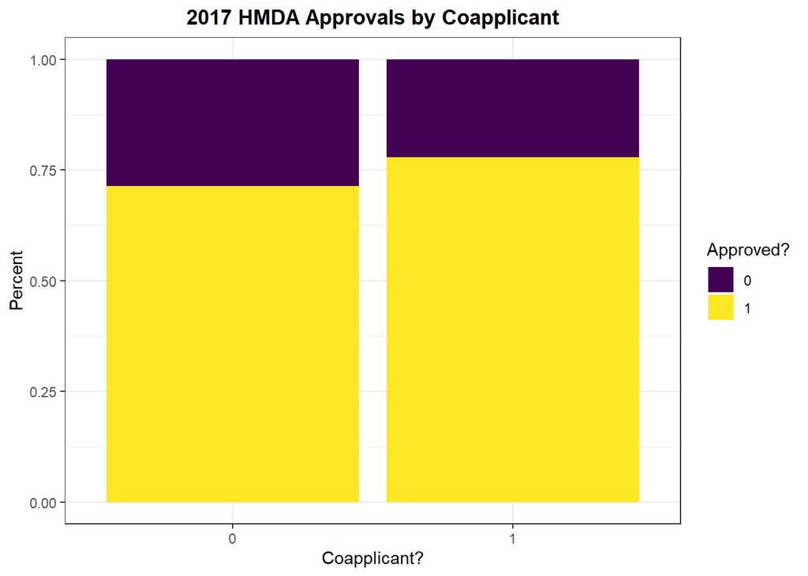

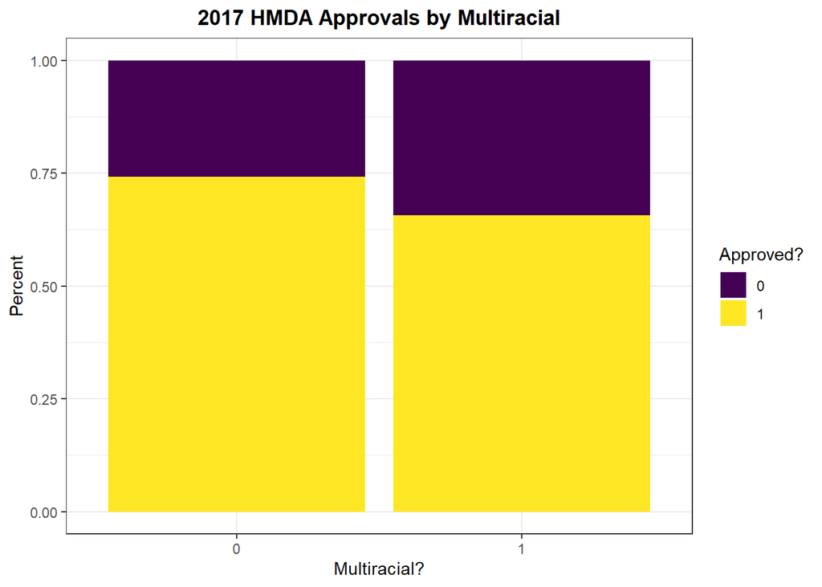

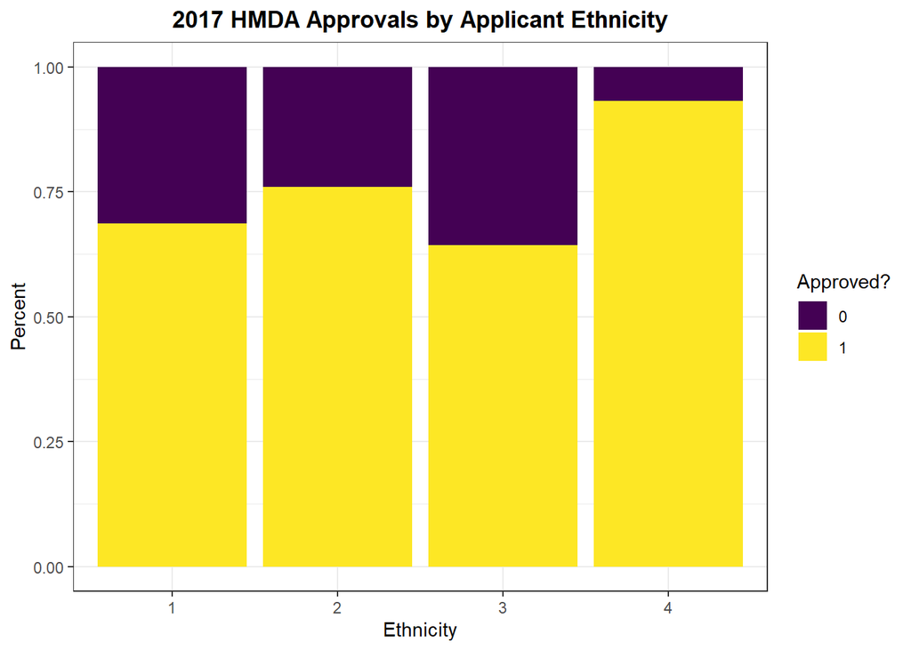

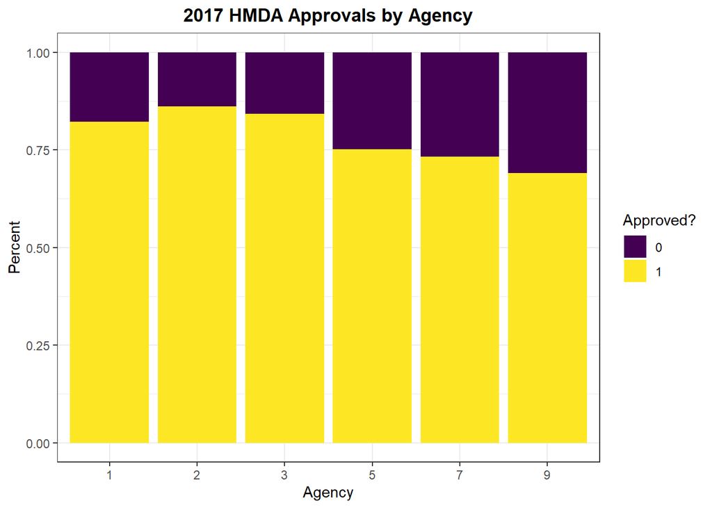

[2 more figures not shown]

Now there certainly appears that some features may influence the mortgage approval rates.

The state and county codes are included with the data. They can be converted into FIPS codes. The data can then be exported to Tableau to create a graphical map.

```r
hmda_reduced$state_code <- str_pad(hmda_reduced$state_code, 2, pad = "0")
hmda_reduced$county_code <- str_pad(hmda_reduced$county_code, 3, pad = "0")

hmda_reduced$fips <- paste0(hmda_reduced$state_code,hmda_reduced$county_code)
hmda_reduced$fips <- as.factor(hmda_reduced$fips)

str(hmda_reduced)
```

```
## Classes 'data.table' and 'data.frame':   10502531 obs. of  36 variables:
##  $ agency_code                   : Factor w/ 6 levels "1","2","3","5",..: 6 5 4 6 3 5 5 6 5 5 ...
##  $ loan_type                     : Factor w/ 4 levels "1","2","3","4": 1 3 1 1 2 3 1 2 3 1 ...
##  $ property_type                 : Factor w/ 3 levels "1","2","3": 1 1 1 1 1 1 1 1 1 2 ...
##  $ loan_purpose                  : Factor w/ 3 levels "1","2","3": 3 3 2 3 1 3 3 1 1 1 ...
##  $ owner_occupancy               : Factor w/ 3 levels "1","2","3": 1 1 1 2 1 1 1 1 1 1 ...
##  $ loan_amount_000s              : int  9 161 90 41 76 186 106 92 94 77 ...
##  $ preapproval                   : Factor w/ 3 levels "1","2","3": 3 3 3 3 3 3 3 1 2 3 ...
##  $ action_taken                  : Factor w/ 8 levels "1","2","3","4",..: 3 5 1 1 1 1 1 1 1 3 ...
##  $ msamd                         : Factor w/ 748 levels "10140","10180",..: 446 446 446 446 446 446 446 446 446 446 ...
##  $ state_code                    : chr  "01" "01" "01" "01" ...
##  $ county_code                   : chr  "001" "001" "001" "001" ...
##  $ census_tract_number           : Factor w/ 23832 levels "1","1.01","1.02",..: 4270 4270 4270 4270 4270 4270 4270 4270 4270 4270 ...
##  $ applicant_ethnicity           : Factor w/ 4 levels "1","2","3","4": 2 2 2 2 2 2 2 2 2 3 ...
##  $ co_applicant_ethnicity        : Factor w/ 5 levels "1","2","3","4",..: 5 1 2 2 5 5 5 5 5 3 ...
```

[output cut: 23 more lines]

```r
write.csv(hmda_reduced,"testcs.csv")
```

Lastly, produce a few plots showing the relationship between applicant income and race/ethnicity/sex:

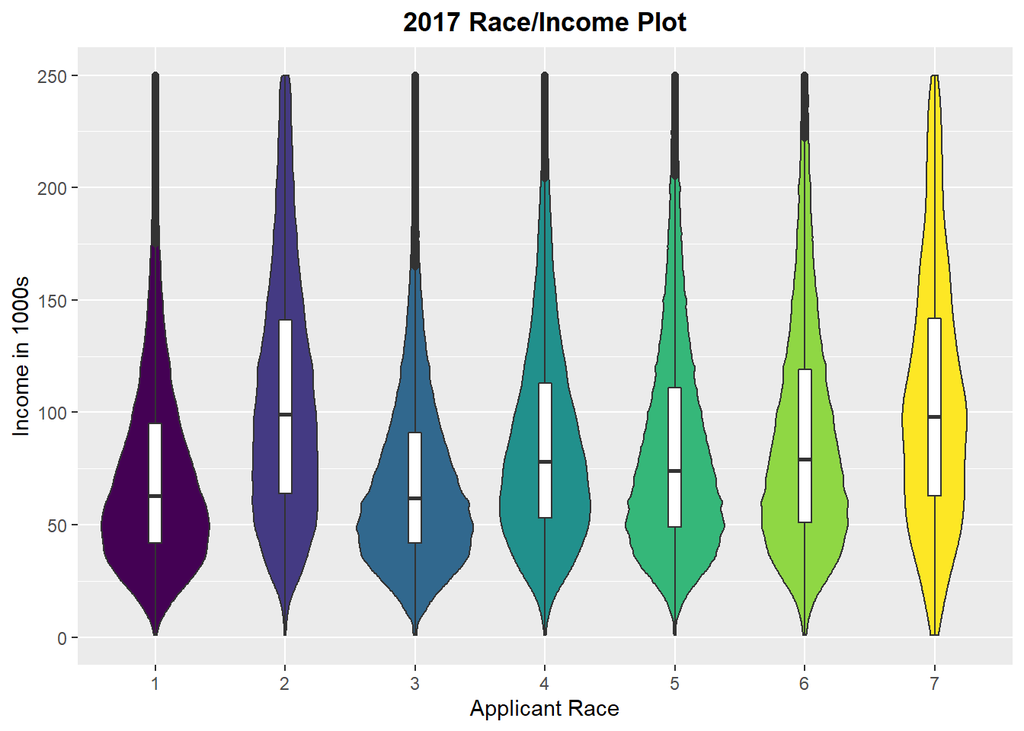

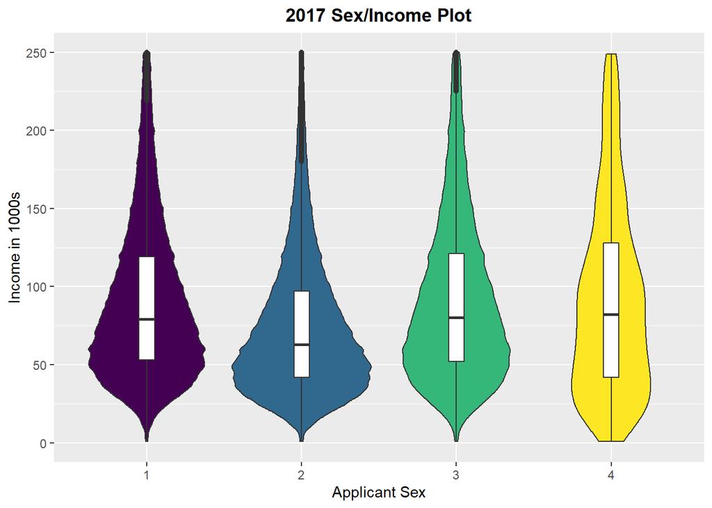

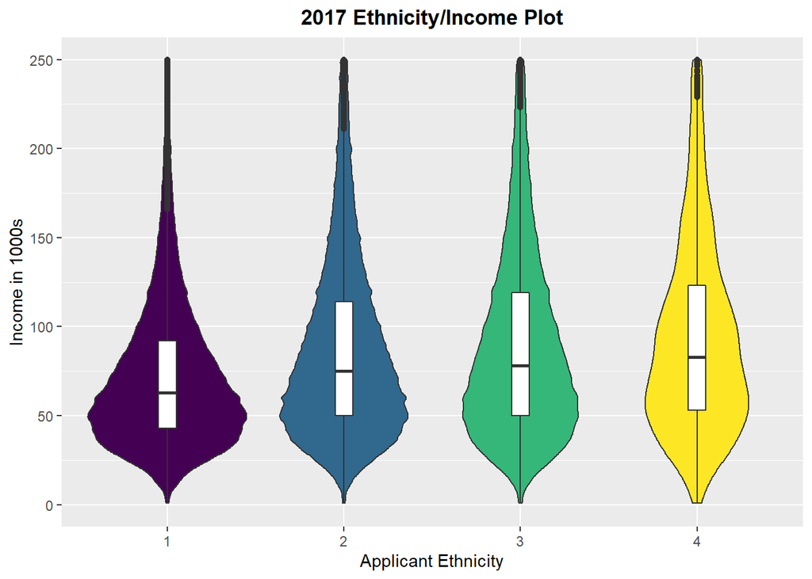

## Data Cleaning

There are still a lot of features. Some more of them can be removed.

Remove denial reason(s), since you cannot have a reason unless application was rejected; even in those cases many rejections had no denial reasons listed. Additionally, some features had many values that were NA or were almost all the same value; those can also be dropped.

Due to performance/hardware constraints, categorical features with many different factors need to also be dropped. FIPS is dropped, for example, but the numerical features based on location remain. 10.5 million observations is still excessive, so take a 1 million observation subset to start with.

```r
hmda_ml <- subset(hmda_reduced, select=-c(denial_reason_1,denial_reason_2,denial_reason_3,
                                        rate_spread,msamd,census_tract_number))
str(hmda_ml)
```

```
## Classes 'data.table' and 'data.frame':   10502531 obs. of  30 variables:
##  $ agency_code                   : Factor w/ 6 levels "1","2","3","5",..: 6 5 4 6 3 5 5 6 5 5 ...
##  $ loan_type                     : Factor w/ 4 levels "1","2","3","4": 1 3 1 1 2 3 1 2 3 1 ...
##  $ property_type                 : Factor w/ 3 levels "1","2","3": 1 1 1 1 1 1 1 1 1 2 ...
##  $ loan_purpose                  : Factor w/ 3 levels "1","2","3": 3 3 2 3 1 3 3 1 1 1 ...
##  $ owner_occupancy               : Factor w/ 3 levels "1","2","3": 1 1 1 2 1 1 1 1 1 1 ...
##  $ loan_amount_000s              : int  9 161 90 41 76 186 106 92 94 77 ...
##  $ preapproval                   : Factor w/ 3 levels "1","2","3": 3 3 3 3 3 3 3 1 2 3 ...
##  $ action_taken                  : Factor w/ 8 levels "1","2","3","4",..: 3 5 1 1 1 1 1 1 1 3 ...
##  $ state_code                    : chr  "01" "01" "01" "01" ...
##  $ county_code                   : chr  "001" "001" "001" "001" ...
##  $ applicant_ethnicity           : Factor w/ 4 levels "1","2","3","4": 2 2 2 2 2 2 2 2 2 3 ...
##  $ co_applicant_ethnicity        : Factor w/ 5 levels "1","2","3","4",..: 5 1 2 2 5 5 5 5 5 3 ...
##  $ applicant_race_1              : Factor w/ 7 levels "1","2","3","4",..: 5 5 5 5 5 5 5 3 5 5 ...
##  $ co_applicant_race_1           : Factor w/ 8 levels "1","2","3","4",..: 8 5 5 5 8 8 8 8 8 5 ...
```

[output cut: 17 more lines]

```r
summary(hmda_ml)
```

```
##  agency_code loan_type   property_type loan_purpose owner_occupancy
##  1: 399528   1:7695975   1:9990781     1:5457050    1:9402501
##  2: 322747   2:1688464   2: 467646     2: 966613    2:1054469
##  3: 984694   3: 956251   3:  44104     3:4078868    3:  45561
##  5: 892756   4: 161841
##  7:5352576
##  9:2550230
##
##  loan_amount_000s  preapproval  action_taken      state_code
##  Min.   :      1   1: 441354   1      :7339057   Length:10502531
##  1st Qu.:    104   2:1685179   3      :2009743   Class :character
##  Median :    180   3:8375998   5      : 601148   Mode  :character
##  Mean   :    247               2      : 409797
##  3rd Qu.:    286               7      : 106680
##  Max.   :3400000               8      :  36106
##  NA's   :2913                  (Other):      0
##  county_code        applicant_ethnicity co_applicant_ethnicity applicant_race_1
##  Length:10502531    1:1088166           1: 432868              1:  89350
##  Class :character   2:8011794           2:3482016              2: 550846
##  Mode  :character   3:1241064           3: 599437              3: 821148
##                     4: 161507           4:  12556              4:  47530
##                                         5:5975654              5:7526154
##                                                                6:1309894
##                                                                7: 157609
##  co_applicant_race_1 applicant_sex co_applicant_sex applicant_income_000s
##  8      :5975653     1:6504692     1: 938242        Min.   :     1.0
##  5      :3383507     2:3061118     2:3199256        1st Qu.:    50.0
##  6      : 619293     3: 779027     3: 378504        Median :    78.0
##  2      : 251022     4: 157694     4:  10874        Mean   :   112.9
##  3      : 202763                   5:5975655        3rd Qu.:   122.0
##  1      :  30700                                    Max.   :610715.0
##  (Other):  39593                                    NA's   :638149
##  purchaser_type    hoepa_status lien_status   population
##  0      :5164679   1:    3538   1:9744595   Min.   :    0
##  1      :1381310   2:10498993   2: 362431   1st Qu.: 3835
##  2      : 971881                3: 395505   Median : 5139
##  3      : 907204                4:      0   Mean   : 5684
##  7      : 819896                            3rd Qu.: 6752
##  6      : 733572                            Max.   :53812
##  (Other): 523989                            NA's   :253607
```

[output cut: 9 more lines]

```
##  Min.   :    0                  Min.   :    0                 0:10430042
##  1st Qu.:  926                  1st Qu.: 1343                 1:   72489
##  Median : 1319                  Median : 1818
##  Mean   : 1461                  Mean   : 2001
##  3rd Qu.: 1803                  3rd Qu.: 2419
##  Max.   :19529                  Max.   :25391
##  NA's   :253629                 NA's   :253629
##  coapplicant approved         fips
##  0:5975653   0:2717571   06037  : 253258
##  1:4526878   1:7784960   04013  : 189891
##                          NANA   : 184169
##                          17031  : 140447
##                          06073  : 114073
##                          48201  : 104860
##                          (Other):9515833
```

```r
# Very long computational time, unfortunately remove features with large # of factors
# Also hoepa_status, which is almost always 2
hmda_ml <- subset(hmda_ml, select=-c(state_code,county_code,fips,hoepa_status))

set.seed(1)
hmda_ml <- hmda_ml[sample(.N,1000000)]
# write.csv(hmda_ml,"testset1.csv")
# hmda_ml <- fread("testset1.csv")
# hmda_ml$V1 <- NULL

str(hmda_ml)
```

```
## Classes 'data.table' and 'data.frame':   1000000 obs. of  26 variables:
##  $ agency_code                   : Factor w/ 6 levels "1","2","3","5",..: 6 5 1 3 5 6 5 3 5 5 ...
##  $ loan_type                     : Factor w/ 4 levels "1","2","3","4": 1 1 1 1 1 1 1 1 2 2 ...
##  $ property_type                 : Factor w/ 3 levels "1","2","3": 1 1 1 1 1 1 2 1 1 1 ...
##  $ loan_purpose                  : Factor w/ 3 levels "1","2","3": 2 3 1 3 2 1 1 1 1 3 ...
##  $ owner_occupancy               : Factor w/ 3 levels "1","2","3": 2 1 1 1 1 1 1 1 1 1 ...
##  $ loan_amount_000s              : int  450 478 800 424 251 173 44 265 167 203 ...
##  $ preapproval                   : Factor w/ 3 levels "1","2","3": 3 3 3 3 3 2 3 3 3 3 ...
##  $ action_taken                  : Factor w/ 8 levels "1","2","3","4",..: 3 3 1 1 1 1 3 1 1 1 ...
##  $ applicant_ethnicity           : Factor w/ 4 levels "1","2","3","4": 2 2 2 2 3 2 3 2 2 1 ...
##  $ co_applicant_ethnicity        : Factor w/ 5 levels "1","2","3","4",..: 5 5 5 5 5 2 1 2 5 5 ...
##  $ applicant_race_1              : Factor w/ 7 levels "1","2","3","4",..: 5 6 5 5 6 5 5 5 5 5 ...
##  $ co_applicant_race_1           : Factor w/ 8 levels "1","2","3","4",..: 8 8 8 8 8 5 5 5 8 8 ...
##  $ applicant_sex                 : Factor w/ 4 levels "1","2","3","4": 2 2 1 1 3 2 2 1 2 1 ...
##  $ co_applicant_sex              : Factor w/ 5 levels "1","2","3","4",..: 5 5 5 5 5 1 2 2 5 5 ...
##  $ applicant_income_000s         : int  44 8 448 444 91 39 43 94 37 NA ...
##  $ purchaser_type                : Factor w/ 10 levels "0","1","2","3",..: 1 1 8 4 4 1 1 8 3 3 ...
##  $ lien_status                   : Factor w/ 4 levels "1","2","3","4": 1 1 1 1 1 1 1 1 1 1 ...
##  $ population                    : int  5200 3627 5258 4119 4894 5742 3559 11083 3772 2170 ...
##  $ minority_population           : num  86.31 45.22 23.34 5.41 27.5 ...
##  $ hud_median_family_income      : int  64300 63200 104800 90200 67700 73600 56000 67400 70000 91100 ...
##  $ tract_to_msamd_income         : num  104.5 193.1 172.2 96.2 131.9 ...
##  $ number_of_owner_occupied_units: int  877 1119 1525 1410 1380 1533 869 3267 952 594 ...
##  $ number_of_1_to_4_family_units : int  1196 1298 1833 3099 1635 2553 1350 4040 1261 704 ...
##  $ multirace                     : Factor w/ 2 levels "0","1": 1 1 1 1 1 1 1 1 1 1 ...
##  $ coapplicant                   : Factor w/ 2 levels "0","1": 1 1 1 1 1 2 2 2 1 1 ...
##  $ approved                      : Factor w/ 2 levels "0","1": 1 1 2 2 2 2 1 2 2 2 ...
##  - attr(*, ".internal.selfref")=<externalptr>
```

```r
summary(hmda_ml)
```

```
##  agency_code loan_type  property_type loan_purpose owner_occupancy
##  1: 38020    1:733022   1:951061      1:519985     1:895162
##  2: 30503    2:160679   2: 44765      2: 92244     2:100543
##  3: 93639    3: 90772   3:  4174      3:387771     3:  4295
##  5: 85333    4: 15527
##  7:510008
##  9:242497
##
##  loan_amount_000s  preapproval  action_taken    applicant_ethnicity
##  Min.   :      1   1: 42010    1      :698571   1:103344
##  1st Qu.:    104   2:161145    3      :191845   2:762750
##  Median :    180   3:796845    5      : 56760   3:118459
##  Mean   :    251               2      : 39265   4: 15447
##  3rd Qu.:    286               7      : 10121
##  Max.   :3400000               8      :  3438
##  NA's   :277                   (Other):     0
##  co_applicant_ethnicity applicant_race_1 co_applicant_race_1 applicant_sex
##  1: 41008               1:  8320         8      :569520      1:618840
##  2:330786               2: 52026         5      :321213      2:291581
##  3: 57473               3: 78465         6      : 59355      3: 74525
##  4:  1213               4:  4613         2      : 23817      4: 15054
##  5:569520               5:716456         3      : 19365
##                         6:125064         1      :  2918
##                         7: 15056         (Other):  3812
##  co_applicant_sex applicant_income_000s purchaser_type   lien_status
##  1: 89571         Min.   :     1.0      0      :491686   1:927613
##  2:303556         1st Qu.:    50.0      1      :131255   2: 34503
##  3: 36300         Median :    78.0      2      : 92467   3: 37884
##  4:  1053         Mean   :   113.3      3      : 86320   4:     0
##  5:569520         3rd Qu.:   122.0      7      : 78304
##                   Max.   :293391.0      6      : 70262
##                   NA's   :60919         (Other): 49706
##    population    minority_population hud_median_family_income
##  Min.   :    0   Min.   :  0.00      Min.   : 15800
##  1st Qu.: 3837   1st Qu.: 11.38      1st Qu.: 61400
##  Median : 5142   Median : 24.27      Median : 67900
##  Mean   : 5686   Mean   : 32.28      Mean   : 70605
##  3rd Qu.: 6755   3rd Qu.: 47.17      3rd Qu.: 77500
##  Max.   :53812   Max.   :100.00      Max.   :131500
##  NA's   :24122   NA's   :24125       NA's   :24122
##  tract_to_msamd_income number_of_owner_occupied_units
##  Min.   :  0.00        Min.   :    0
##  1st Qu.: 86.54        1st Qu.:  926
##  Median :107.60        Median : 1319
##  Mean   :113.06        Mean   : 1460
##  3rd Qu.:132.96        3rd Qu.: 1802
##  Max.   :507.47        Max.   :19529
##  NA's   :24122         NA's   :24125
##  number_of_1_to_4_family_units multirace  coapplicant approved
##  Min.   :    0                 0:993206   0:569520    0:258726
##  1st Qu.: 1344                 1:  6794   1:430480    1:741274
##  Median : 1818
##  Mean   : 2001
##  3rd Qu.: 2421
##  Max.   :25391
##  NA's   :24125
```

```r
rm(hmda_reduced)
```

### Imputation

There are still NA values remaining in the data. Visualize and impute the missing data with mice library, before exporting to CSV for easy access:

[figure not shown]

NA Pattern

```r
md.pattern(hmda_ml,rotate.names = TRUE)
hmda_fill <- complete(mice(hmda_ml, maxit = 1))
write.csv(hmda_fill,"testset1_imp.csv")
```